# Question

Let $f$ represent a quartic (4th degree) polynomial with integer coefficients.

$$f(x)~=~{5}x^{4}-{2}x^{3}+{172}x^{2}+{290}x+{111}$$

One of the roots is $1-6i$, where $i=\sqrt{-1}$.

$$f(1-6i)~=~0$$

This quartic polynomial has at least 1 rational root. Find all the rational roots.

## Answerlist

- $-1$
- $-2$
- $-3$
- $-4$
- $-5$
- $-6$
- $-7$
- $-8$
- $-9$
- $\frac{-1}{2}$
- $\frac{-1}{3}$
- $\frac{-1}{4}$
- $\frac{-1}{5}$
- $\frac{-1}{6}$
- $\frac{-1}{7}$
- $\frac{-1}{8}$
- $\frac{-1}{9}$
- $\frac{-2}{3}$
- $\frac{-2}{5}$
- $\frac{-2}{7}$
- $\frac{-2}{9}$
- $\frac{-3}{2}$
- $\frac{-3}{4}$
- $\frac{-3}{5}$
- $\frac{-3}{7}$
- $\frac{-3}{8}$
- $\frac{-4}{3}$
- $\frac{-4}{5}$
- $\frac{-4}{7}$
- $\frac{-4}{9}$
- $\frac{-5}{2}$
- $\frac{-5}{3}$
- $\frac{-5}{4}$
- $\frac{-5}{6}$
- $\frac{-5}{7}$
- $\frac{-5}{8}$
- $\frac{-5}{9}$
- $\frac{-6}{5}$
- $\frac{-6}{7}$
- $\frac{-7}{2}$
- $\frac{-7}{3}$
- $\frac{-7}{4}$
- $\frac{-7}{5}$
- $\frac{-7}{6}$
- $\frac{-7}{8}$
- $\frac{-7}{9}$
- $\frac{-8}{3}$
- $\frac{-8}{5}$
- $\frac{-8}{7}$
- $\frac{-8}{9}$
- $\frac{-9}{2}$
- $\frac{-9}{4}$
- $\frac{-9}{5}$
- $\frac{-9}{7}$
- $\frac{1}{2}$
- $\frac{1}{3}$
- $\frac{1}{4}$
- $\frac{1}{5}$
- $\frac{1}{6}$
- $\frac{1}{7}$
- $\frac{1}{8}$
- $\frac{1}{9}$
- $\frac{2}{3}$
- $\frac{2}{5}$
- $\frac{2}{7}$
- $\frac{2}{9}$
- $\frac{3}{2}$
- $\frac{3}{4}$
- $\frac{3}{5}$
- $\frac{3}{7}$
- $\frac{3}{8}$
- $\frac{4}{3}$
- $\frac{4}{5}$
- $\frac{4}{7}$
- $\frac{4}{9}$
- $\frac{5}{2}$
- $\frac{5}{3}$
- $\frac{5}{4}$
- $\frac{5}{6}$
- $\frac{5}{7}$
- $\frac{5}{8}$
- $\frac{5}{9}$
- $\frac{6}{5}$
- $\frac{6}{7}$
- $\frac{7}{2}$
- $\frac{7}{3}$
- $\frac{7}{4}$
- $\frac{7}{5}$
- $\frac{7}{6}$
- $\frac{7}{8}$
- $\frac{7}{9}$
- $\frac{8}{3}$
- $\frac{8}{5}$
- $\frac{8}{7}$
- $\frac{8}{9}$
- $\frac{9}{2}$
- $\frac{9}{4}$
- $\frac{9}{5}$
- $\frac{9}{7}$
- $1$
- $2$
- $3$
- $4$
- $5$
- $6$
- $7$
- $8$
- $9$

# Solution

We know that complex roots show up as complex-conjugate pairs. So, since $1-6i$ is a root, we also know $1+6i$ is another root. This accounts for two roots.

The [fundamental theorem of algebra](https://en.wikipedia.org/wiki/Fundamental_theorem_of_algebra) promises “every non-zero, single-variable, degree n polynomial with complex coefficients has, counted with multiplicity, exactly n complex roots.”

So, we know there will be a total of 4 roots.

Thus, we should be able to express $f(x)$ in a semi-factored form (with yet to be determined coefficients $a$ and $b$ and $c$).

$$f(x)~=~(ax^2+bx+c)(x-(1-6i))(x-(1+6i))$$

Distribute the negatives across the inner parentheses.

$$f(x)~=~(ax^2+bx+c)(x-1+6i)(x-1-6i)$$

Now use a box to multiply the two complex factors.

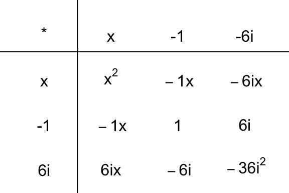

Remember, $i^2=-1$, so $-36i^2=36$. Combine like terms.

$$f(x)~=~(ax^2+bx+c)(x^2-2x+37)$$

Now… we know this semi-factored form and the standard form are equivalent expressions.

$$(ax^2+bx+c)(x^2-2x+37)~\equiv~{5}x^{4}-{2}x^{3}+{172}x^{2}+{290}x+{111}$$

So, we can divide both sides by $x^{2}-{2}x+{37}$.

$$ax^2+bx+c~=~\frac{{5}x^{4}-{2}x^{3}+{172}x^{2}+{290}x+{111}}{x^{2}-{2}x+{37}}$$

Use the box method to divide.

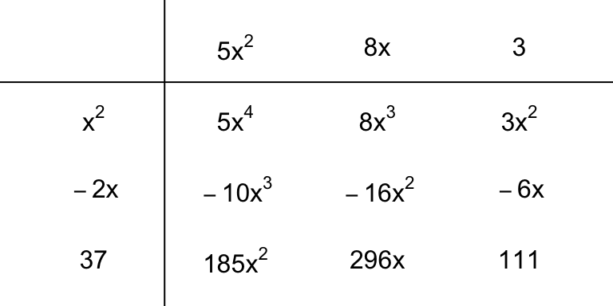

So,

$$f(x)~=~({5}x^{2}+{8}x+{3})(x^{2}-{2}x+{37})$$

We have expressed the quartic polynomial as the product of two quadratic polynomials. Remember, our goal is to find solutions to $f(x)=0$. We already know that $x=1-6i$ and $x=1+6i$ are solutions, and those two roots correspond to the factor $x^{2}-{2}x+{37}$ equaling 0. By setting the other quadratic factor, ${5}x^{2}+{8}x+{3}$, equal to zero, we can find the other roots.

$${5}x^{2}+{8}x+{3}=0$$

Use the quadratic formula: if $ax^2+bx+c=0$ then $x=\frac{-b\pm\sqrt{b^2-4ac}}{2a}$.

$$x=\frac{-(8)\pm\sqrt{(8)^2-4(5)(3)}}{2(5)}$$

Simplify.

$$x=\frac{-8\pm\sqrt{64-60}}{10}$$

Simplify.

$$x=\frac{-8\pm\sqrt{4}}{10}$$

Simplify.

$$x=\frac{-8\pm2}{10}$$

Split into two different fraction.

$$\begin{align}
x&=\frac{-8+2}{10} &&& x&=\frac{-8-2}{10} \\\\
x&=\frac{-6}{10} &&& x&=\frac{-10}{10} \\\\
x&=\frac{-3}{5} &&& x&=-1
\end{align}$$

Now we know all four roots. We could express $f$ in fully factored form.

$$f(x)~=~(x+{1})({5}x+{3})(x-(1-6i))(x-(1+6i))$$

Or, if you are not into complex factors, you could also express $f$ as factored as possible with integer coefficients.

$$f(x)~=~(x+{1})({5}x+{3})(x^{2}-{2}x+{37})$$

Anyway, the two rational roots are $-1$ and $\frac{-3}{5}$.

# Meta-information

extype: mchoice exsolution: 100000000000000000000001000000000000000000000000000000000000000000000000000000000000000000000000000000000000 exname: x_standard_2_rat_1_comp